# Topic Modelling with LDA

Arga Adyatama and Joe Nathan Christian

4/17/2020

# Topic Modelling

## Background

Natural Language Processing (NLP) is a branch of artificial intelligence that is steadily growing both in terms of research and market values[^1]. The ultimate objective of NLP is to read, decipher, understand, and make sense of the human languages in a manner that is valuable[^2]. The are many applications of NLP in various industries, such as:

- SPAM email detection
- Sentiment Analysis
- Text summarization
- Text Generation
- Topic Modelling

On this occation, we will learn about Topic Modelling and it’s application in a real case. Before we start the journey, let’s consider a simple example.

Suppose that we have the following word cloud, can you guess what these words have in common?

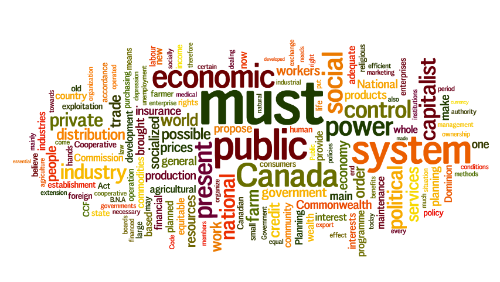

The interpretation may differ from one persone to another, but most of you must be agree that the word cloud has a common theme or topic. Perhaps you might say that it is related to economics, or politics, or business. The real theme of the words is unkown, but we as the observer are giving the group of words a meaningful and understandable topic. This activity is what we call as **Topic Modelling**.

> In text mining, we often have collections of documents, such as blog posts or news articles, that we’d like to divide into natural groups so that we can understand them separately. Topic modeling is a method for unsupervised classification of such documents, similar to clustering on numeric data, which finds natural groups of items even when we’re not sure what we’re looking for.

There are many application of Topic Modelling, even outside of the field of NLP. Some applications of Topic Modelling derived from *Boyd-Graber et al.*[^3] and *Blei et al.*[^4] includes:

- Discover different topic in large corpus of document
- Sentiment Analysis
- Understanding Stance and Polarization in Social Media
- Identify new innovation/discovery in scientific research paper
- Document Classification
- Recommender System

Below is another example of topic modeling from *Blei et al.* where the top words for each topic (arts, budgets, children, and education) are shown. The colored text on the lower part of the figure illustrate that a single document is a collection of words with various topic.

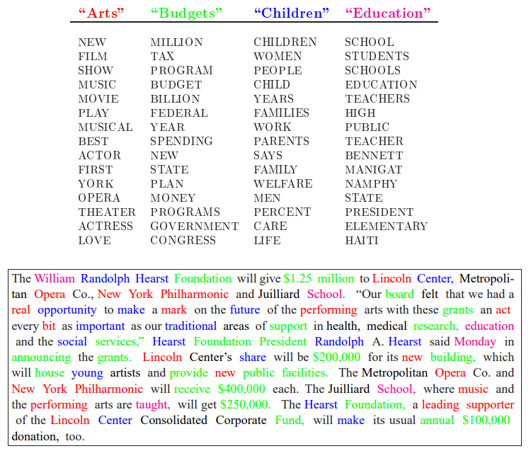

The popular algorithm for Topic Modeling is **Latent Dirichlet Allocation (LDA)**, which is developed by [**Blei et al.**](http://www.jmlr.org/papers/volume3/blei03a/blei03a.pdf) . This algorithm can be understood in this two simple properties[^5]:

- **Every document is a mixture of topics**. We imagine that each document may contain words from several topics in particular proportions. For example, in a two-topic model we could say “Document 1 is 90% topic A and 10% topic B, while Document 2 is 30% topic A and 70% topic B.”
- **Every topic is a mixture of words**. For example, we could imagine a two-topic model of American news, with one topic for “politics” and one for “entertainment.” The most common words in the politics topic might be “President”, “Congress”, and “government”, while the entertainment topic may be made up of words such as “movies”, “television”, and “actor”. Importantly, words can be shared between topics; a word like “budget” might appear in both equally.

**The objective** of this article is as follows:

- Understand the advantage and disadvantage of LDA
- Understand how to train and evaluate Topic Modelling with LDA
- Learn how to implement Topic Modeling in a corpus of document
- Learn how to interpret and explore the output of LDA

## Library and Setup

Below is the required package to reproduce the code in this article.

```r
# Data Wrangling
library(tidyverse)

# Text Processing
library(tm)
library(corpus)
library(tidytext)
library(textclean)
library(lubridate)
library(hunspell)
library(SnowballC)
library(textmineR)
library(scales)

# Visualization
library(ggwordcloud)

# Modeling and Evaluation
library(randomForest)
library(e1071)
library(yardstick)

options(scipen = 999)
```

# General Concept

This section illustrate the first principle and the workflow of Topic Modelling with LDA

## Latent Dirichlet Allocation (LDA)

LDA is a generative probabilistic model of a corpus. Compared to other topic modelling methods such as the unigram model, Latent Semantic Analysis (LSA), and Probabilistic Latent Semantic Analysis (pLSA), the advantage and disadvantage of LDA is as follows:

**Advantages**

- Can find latent topic inside documents
- Supervised learning requires a true label, which may not be available
- LDA is easy to train
- LDA can be paired with word2vec to retain the word representation.
- LDA give interpretable topics

**Disadvantages**

- Only considers document as a bag of words and ignore syntactic information (e.g. word order) and semantic information (e.g. the multiplicity of meanings of a given word)
- Fixed number of topics
- Uncorrelated topics (Dirichlet topic distribution cannot capture correlations)
- Static (no evolution of topics over time)

We will break the concept one step at a time. Back to the last section, the main principle of LDA is these 2 concepts:

- **Every document is a mixture of topics**
- **Every topic is a mixture of words**

We will go to the first concept. LDA does not give a clear answer wether a document belong to a certain topics because a document is considered as a mixture of topics. In a single document, we may find several topics. A news about the financial crisis of 2008 may consists of economics, politics and social topics, blended in a single article that discuss about the market value, the government response and the impact of high unemployment rate. Thus, as an example, a document may consists of 30% economics, 60% politics, and 10% social topics. The percentage of each topic represent the probability of the document to belong a certain topic. Therefore, we can imagine the mixture of topics as a probability distribution such as the following table:

```r
set.seed(123)
data.frame(news = 1:5,
           economics = runif(5, max = 0.5),
           politics = runif(5, max = 0.5)) %>%
   mutate(social = 1 - (economics + politics))
```

| news | economics | politics | social |
| --- | --- | --- | --- |
| 1 | 0.1437888 | 0.02277825 | 0.8334330 |
| 2 | 0.3941526 | 0.26405274 | 0.3417947 |
| 3 | 0.2044885 | 0.44620952 | 0.3493020 |
| 4 | 0.4415087 | 0.27571751 | 0.2827738 |
| 5 | 0.4702336 | 0.22830737 | 0.3014590 |

The first news has a 14% chance to be an economics news, 2% of politics news and 83% of social news. The second news has a 39% chance to be an economics news, 26% of politics news and 34% of social news and so on. Higher probability means that the document can be represented by the topic.

The word *Latent* in Latent Dirichlet Allocation refers to the latent or hidden structure inside a document. As we have seen in the previous section, we intuively think that a group of words can have a central theme or topics. Therefore, according to the second principle, a topic is a mixture of words, where a certain words have a strong association with a certain topic. For example, the word *President* have a strong signal that it belong to the topic of politics, or the word *Loan* and *Interest* have a strong signal toward economics topic. Just as a document has a probability distribution for each topic, a topic also has a probability distribution for each words/terms. LDA assume that a document is a bag of words, thus we do not care about the word sequence.

An LDA model is built based on these two principles and has the following graphical structures.

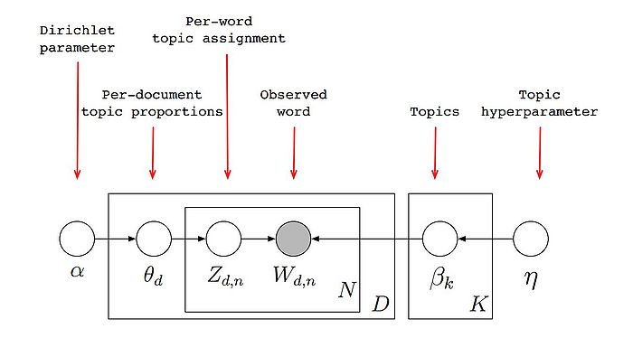

Notation:

LDA belong to a hierarchical bayesian model. A bayesian model has a prior and a posterior. A prior means the probability distribution of certain things before we see the data. For example, we may belief that the probability distribution for a roll of dice is uniformly distributed with every value have the same probability to appear. We have this assumption before we try to roll the dice. Meanwhile, the posterior probability reflects the probability distribution after we see the data, after we roll the dice. For example, after we toss the dice for 10,000 times, the number 5 appears for more than 5,000 tosses. This may change our belief that the value for each side is uniformly distributed, since a single side of the dice has a high chance to appear and we might be suspicious that the dice is not fair. We can calculate the posterior probability using the Bayes Theorem[^6], which we will not discuss on this article. The concept of prior and posterior probability is important to the understanding of the LDA process.

The LDA model consists of 2 different priors distribution: probability distribution of topic to document (topic-document probability) and probability distribution of words to topics (word-topic probability). The probability distribution for the two priors are not uniform or normal distribution, but a Dirichlet distribution with the $\alpha$ and $\beta$ parameters as well as the number of topics as the input.

The following figure is the illustration of the Dirichlet distribution for each topic to each document. Suppose we have a collection of documents and we are confident that on the corpus we have 3 different topics. Each dot represent a single document and each side of the triangle represent a single topics. The position of each document represent the probability distribution for each topic. We randomly assign the position of each document based on its probability distribution. We can see that document A has a close proximity to the topic of Science. This indicate that document A has a high probability of belong to topic Science and low probability ot belong to Politics or Economy. Meanwhile, document B has a high probability to belong to the topic Economy. Document C is located between Science and Politics, so it has a rather equal probability for those topics and low probability for the topic Economy. The topic D is located at the center of the triangle, which means that it has an equal probability for the three topics.

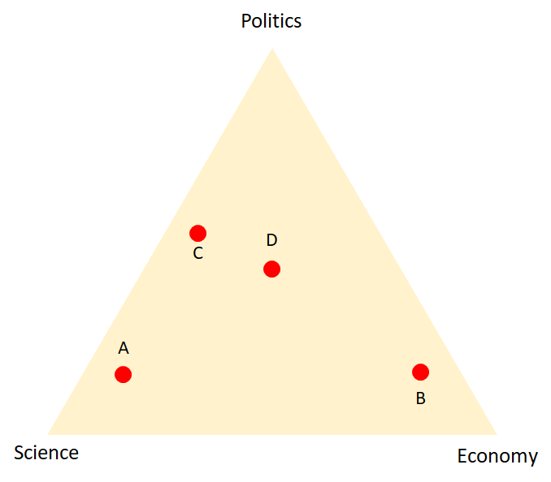

The goal of LDA is to make each document as close as possible toward a certain topics, although it may not always be achieved for all document. If the above graphics represent our prior probability for each document to each topics, the following graphic illustrate the posterior probability where all document is having a strong relation with a certain topics.

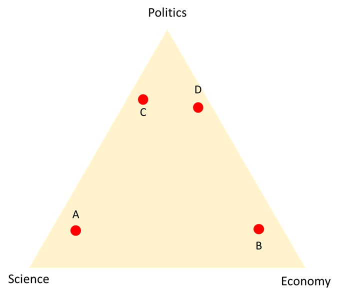

We may translate the probability distribution into the following table:

```r
data.frame(document = c("A","B","C","D"),
           sciences = c(0.8, 0.1, 0.1, 0.1),
           politics = c(0.1, 0.05, 0.85, 0.8),
           economy = c(0.1, 0.85, 0.05, 0.1))
```

| document | sciences | politics | economy |
| --- | --- | --- | --- |
| A | 0.8 | 0.10 | 0.10 |
| B | 0.1 | 0.05 | 0.85 |
| C | 0.1 | 0.85 | 0.05 |
| D | 0.1 | 0.80 | 0.10 |

The second prior distribution is the probability of a topics belong to certain words: word-topic probability. This prior is concerned with what terms that represent what topic? Is there any terms that have strong connection with certain topics? Let’s say we have 4 terms: *President*, *Planet*, *Market*, and *Energy*. Each terms will act as the edge of the triangle. However, since we have more than 3 terms, the shape of the distribution is not a triangle anymore, but a tetrahedron. The following figures illustrate a random assignment of Dirichlet distribution between topics and words.

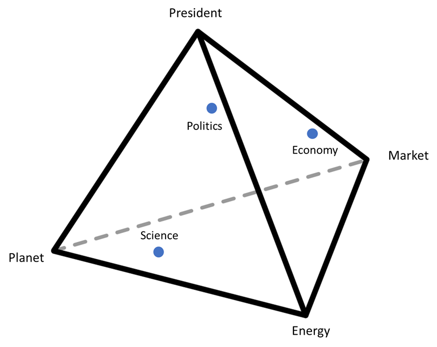

If we translate the position of each topic into a probabilistic value, we get the following table:

```r
data.frame(topic = c("Politics", "Science", "Economy"),
           president = c(0.8, 0.15, 0.1),
           planet = c(0.05, 0.5, 0.05),
           energy = c(0.1, 0.3, 0.15),
           market = c(0.05, 0.05, 0.7))
```

| topic | president | planet | energy | market |
| --- | --- | --- | --- | --- |
| Politics | 0.80 | 0.05 | 0.10 | 0.05 |
| Science | 0.15 | 0.50 | 0.30 | 0.05 |
| Economy | 0.10 | 0.05 | 0.15 | 0.70 |

Based on the table, the terms *President* has strong association with the word politics, *Planet* with Science and *Market* with Economy.

These prior distribution will be used to generate word samples to calculate the posterior probability or the estimate of the true probability.

Let’s go back toward the LDA structure.

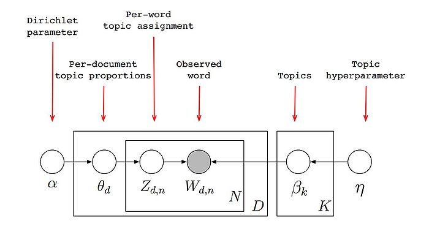

The generative process is the process of generating a document by randomly selecting words from each topic. The rough description of the process is as follows:

1. Randomly choose a distribution over topics
2. For each word in the document
   1. randomly choose a topic from the distribution over topics
   2. randomly choose a word from the corresponding topic (distribution over the vocabulary)

In order to estimate the posterior probability of the topic-document and word-topic distribution, we need to use Gibbs-sampling or Variational Expectation Maximation (VEM). Both are approximate inference method and has its own characteristic.

## Gibbs Sampling

The Gibbs sampling is one of many method to sample data in Bayesian Statistics. The concept of Gibbs sampling in topic modeling is that we assume that all documents and all terms have a prior topics except for a single word, which we will calculate the posterior probability of belonging to certain topics. The algorithm of Gibbs sampling is as follows:

1. For each iteration $i$:

1.1 For each document $d$ and word $n$ currently assigned to $z_{old}$ :

1.1.1 Decrement $n_{d,z_{old}}$ and $v_{z_{old}, w_{d,n}}$

1.1.2 Sample $z_{new} = k$ with probability proportional to $\frac{n_{d,k} + \alpha_k\ v_{k,w_{d,n}} + \lambda_{w_{d,n}}}{\Sigma_i=k^K n_{d,i} +\alpha_i\ \Sigma_i v_{k,i} + \lambda_i}$

1.1.3 Increment $n_{d,z_{new}}$ and $v_{z_{old}, w_{d,n}}$

Notation :

$z_{old}$ : prior/early topic assignment

$z_{new}$ : updated topic assignment

$n_{d,k}$ : Number of times document $d$ uses topic $k$

$v_{k, w_{d,n}}$ : Number of times topic $k$ uses word type $w_{d,n}$

$\alpha_k$ : Dirichlet parameter for document to topic distribution

$\lambda_{w_{d,n}}$ : Dirichlet parameter for topic to word distribution

We will try with an example. Suppose we have a corpus of documents, with one of them is as follows:

> The government put curfew during pandemic

Suppose that the document has a pre-determined topic assignment:

```r
data.frame(
   topic = c(1, 2, 2, 3, 1, 3),
   term = c("the", "government", "put", "curfew", "during", "pandemic")
) %>%
   t() %>%
   as.data.frame()
```

|  | V1 | V2 | V3 | V4 | V5 | V6 |
| --- | --- | --- | --- | --- | --- | --- |
| topic | 1 | 2 | 2 | 3 | 1 | 3 |
| term | the | government | put | curfew | during | pandemic |

The following is the count of words for each topics from all documents inside the corpus:

```r
data.frame(
   term = c("the", "government", "put", "curfew", "during", "pandemic"),
   topic_1 = c(200, 10, 30 ,20, 5, 8),
   topic_2 = c(40, 30, 10, 5, 3, 2),
   topic_3 = c(10, 2, 1, 8, 17, 30)
)
```

| term | topic_1 | topic_2 | topic_3 |
| --- | --- | --- | --- |
| the | 200 | 40 | 10 |
| government | 10 | 30 | 2 |
| put | 30 | 10 | 1 |
| curfew | 20 | 5 | 8 |
| during | 5 | 3 | 17 |
| pandemic | 8 | 2 | 30 |

For the first iteration and the first term, we would like to update the topic assignment for the word *government*.

```r
data.frame(
   topic = c(1, "?", 2, 3, 1, 3),
   document = c("The", "government", "put", "curfew", "during", "pandemic")
) %>%
   t() %>%
   as.data.frame()
```

|  | V1 | V2 | V3 | V4 | V5 | V6 |
| --- | --- | --- | --- | --- | --- | --- |
| topic | 1 | ? | 2 | 3 | 1 | 3 |
| document | The | government | put | curfew | during | pandemic |

1.1.1 Decrement $n_{d,z_{old}}$ and $v_{z_{old}, w_{d,n}}$

The word *government* was assigned as topic 2 earlier so we would omit that assignment and reduce the count of word *government* from the topic 2 by 1 (from 30 to 29).

```r
data.frame(
   term = c("the", "government", "put", "curfew", "during", "pandemic"),
   topic_1 = c(200, 10, 30 ,20, 5, 8),
   topic_2 = c(40, 29, 10, 5, 3, 2),
   topic_3 = c(10, 2, 1, 8, 17, 30)
)
```

| term | topic_1 | topic_2 | topic_3 |
| --- | --- | --- | --- |
| the | 200 | 40 | 10 |
| government | 10 | 29 | 2 |
| put | 30 | 10 | 1 |
| curfew | 20 | 5 | 8 |
| during | 5 | 3 | 17 |
| pandemic | 8 | 2 | 30 |

1.1.2 Sample $z_{new} = k$ with probability proportional to $\frac{n_{d,k} + \alpha_k\ v_{k,w_{d,n}} + \lambda_{w_{d,n}}}{\Sigma_i=k^K n_{d,i} +\alpha_i\ \Sigma_i v_{k,i} + \lambda_i}$

Now we update the topic assignment using the earlier formula. We will get the probability for each topic (k) and then sample the topic. Higher probability means that the word will be likely assigned to that topic.

$$z_{new} = \frac{n_{d,k} + \alpha_k\ v_{k,w_{d,n}} + \lambda_{w_{d,n}}}{\Sigma_{i=k}^K n_{d,i} +\alpha_i\ \Sigma_i v_{k,i} + \lambda_i}$$

Long story short, after we get the sample, we update the topic assignment for the word. For example, based on the sample, the new topic assignment for the word *government* is topic 1.

```r
data.frame(
   topic = c(1, 1, 2, 3, 1, 3),
   document = c("The", "government", "put", "curfew", "during", "pandemic")
) %>%
   t() %>%
   as.data.frame()
```

|  | V1 | V2 | V3 | V4 | V5 | V6 |
| --- | --- | --- | --- | --- | --- | --- |
| topic | 1 | 1 | 2 | 3 | 1 | 3 |
| document | The | government | put | curfew | during | pandemic |

1.1.3 Increment $n_{d,z_{new}}$ and $v_{z_{old}, w_{d,n}}$

```r
data.frame(
   term = c("the", "government", "put", "curfew", "during", "pandemic"),
   topic_1 = c(200, 11, 30 ,20, 5, 8),
   topic_2 = c(40, 29, 10, 5, 3, 2),
   topic_3 = c(10, 2, 1, 8, 17, 30)
)
```

| term | topic_1 | topic_2 | topic_3 |
| --- | --- | --- | --- |
| the | 200 | 40 | 10 |
| government | 11 | 29 | 2 |
| put | 30 | 10 | 1 |
| curfew | 20 | 5 | 8 |
| during | 5 | 3 | 17 |
| pandemic | 8 | 2 | 30 |

# Case Studies

## COVID-19 CBC News

We will try to do a document modelling to find different topics in **CBC News/COVID-19 Articles**. The dataset is acquired from [Kaggle](https://www.kaggle.com/ryanxjhan/cbc-news-coronavirus-articles-march-26) . The context of the dataset is that has the news media been overreacting or under-reacting during the development of COVID-19? What are the media’s main focuses?

We will try to answer this problem by finding latent information inside corpus using Latent Dirichlet Allocation.

### Import Data

```r
covid_news <- data.table::fread("data/covid_news.csv", header = T, encoding = "Latin-1")

glimpse(covid_news)
```

```
## Rows: 2,725
## Columns: 7
## $ V1           <int> 0, 1, 2, 3, 4, 5, 6, 7, 8, 9, 10, 11, 12, 14, 15, 16, 17…
## $ authors      <chr> "['Cbc News']", "['Cbc News']", "['The Associated Press'…
## $ title        <chr> "Coronavirus a 'wake-up call' for Canada's prescription …
## $ publish_date <chr> "2020-03-27 08:00:00", "2020-03-27 01:45:00", "2020-03-2…
## $ description  <chr> "Canadian pharmacies are limiting how much medication ca…
## $ text         <chr> "Canadian pharmacies are limiting how much medication ca…
## $ url          <chr> "https://www.cbc.ca/news/health/covid-19-drug-supply-1.5…
```

Data description:

- **V1**: Document index
- **authors**: The author of the news/articles
- **title**: The title of the news/articles
- **publish_date**: The date when the news/article is published
- **description**: The subtitle or headline of the news/article
- **text**: The full text of the news/article
- **url**: The link of the news/article

Below is the sample of the data.

```r
head(covid_news, 10)
```

| V1 | authors | title | publish_date | description | text | url |
| --- | --- | --- | --- | --- | --- | --- |
| 0 | ['Cbc News'] | Coronavirus a 'wake-up call' for Canada's prescription drug supply | 2020-03-27 08:00:00 | Canadian pharmacies are limiting how much medication can be dispensed to try to prevent shortages, recognizing that most active ingredients for drugs come from India and China and medical supply chain… | Canadian pharmacies are limiting how much medication can be dispensed to try to prevent shortages, recognizing that most active ingredients for drugs come from India and China and medical supply chain… | https://www.cbc.ca/news/health/covid-19-drug-supply-1.5511659 |
| 1 | ['Cbc News'] | Yukon gov't names 2 possible sources of coronavirus exposure | 2020-03-27 01:45:00 | The Yukon government has identified two places in Whitehorse — a church and a dental clinic — where people may have been exposed to the coronavirus in recent weeks. | The Yukon government has identified two places in Whitehorse — a church and a dental clinic — where people may have been exposed to the coronavirus in recent weeks. In a news release Thursday evening,… | https://www.cbc.ca/news/canada/north/yukon-coronavirus-exposure-bethany-church-1.5511906 |
| 2 | ['The Associated Press'] | U.S. Senate passes $2T coronavirus relief package | 2020-03-26 05:13:00 | The Senate has passed an unparalleled $2.2 trillion economic rescue package steering aid to businesses, workers and health care systems engulfed by the coronavirus pandemic | The Senate late Wednesday passed an unparalleled $2.2 trillion US economic rescue package steering aid to businesses, workers and health care systems engulfed by the coronavirus pandemic. The unanimou… | https://www.cbc.ca/news/world/senate-coronavirus-relief-bill-1.5510475 |
| 3 | ['Cbc News'] | Coronavirus: The latest in drug treatment and vaccine development | 2020-03-27 00:36:00 | Scientists around the world are racing to find novel ways to treat, mitigate or prevent infection from the novel coronavirus. Here are the latest developments. | Scientists around the world are racing to find novel ways to treat, mitigate or prevent infection from the novel coronavirus. The response has been especially rapid as the virus has spread unchecked a… | https://www.cbc.ca/news/health/coronavirus-treatment-and-vaccine-development-1.5511346 |
| 4 | ['Cbc News'] | The latest on the coronavirus outbreak for March 26 | 2020-03-26 20:57:00 | The latest on the coronavirus outbreak from CBC News for Thursday, March 26 | Trudeau says rules of Quarantine Act will be enforced to keep people isolated. Canada 'strongly opposed' to U.S. stationing troops near shared border. China prepares to close its borders to foreigners… | https://www.cbc.ca/news/the-latest-on-the-coronavirus-outbreak-for-march-26-1.5511398 |
| 5 | ['Mark Gollom Is A Toronto-Based Reporter With Cbc News. He Covers Canadian', 'U.S. Politics', 'Current Affairs.'] | 'Worse' pandemic on horizon unless world deals with wildlife markets | 2020-03-27 08:00:00 | The continued existence of wildlife markets, which are considered potential breeding grounds for the spread of harmful viruses, means it's just a matter of time before the world is hit with another de… | The continued existence of wildlife markets, which are considered potential breeding grounds for the spread of harmful viruses, means it's just a matter of time before the world is hit with another de… | https://www.cbc.ca/news/world/wildlife-markets-china-coronavirus-pandemic-1.5510045 |
| 6 | ['Cbc News'] | What you need to know about COVID-19 in Ottawa on Friday, March 27 | 2020-03-27 08:00:00 | CBC Ottawa's latest roundup of key points during the coronavirus pandemic. | Recent developments: Two new cases in western Quebec; Ontario has not released locations of new cases. Federal government covering 75 per cent of staff wages for small businesses. Brockville now has C… | https://www.cbc.ca/news/canada/ottawa/covid19-coronavirus-ottawa-symptoms-information-march-27-1.5511735 |
| 7 | ['The Associated Press'] | Michigan hospitals jammed as coronavirus cases, deaths rise | 2020-03-26 11:02:00 | Michigan hospitals are bracing for a surge of coronavirus cases as infections rise to at least 2,294. | Michigan hospitals are bracing for a surge of coronavirus cases as infections rise to at least 2,294. Deaths jumped to 43 from 24. Eighty-five per cent of all cases were reported in Wayne, Oakland and… | https://www.cbc.ca/news/canada/windsor/michigan-hospitals-coronavirus-1.5510518 |
| 8 | ['Thomson Reuters'] | U.S. coronavirus cases now highest in the world | 2020-03-26 14:55:00 | The number of confirmed COVID-19 cases in the U.S. rose to 81,378 on Thursday — more than any other country, overtaking both Italy and China — while the death toll passed the 1,000 mark, according to … | The number of confirmed COVID-19 cases in the U.S. rose to 83,836 on Thursday — more than any other country, overtaking both Italy and China — while the death toll passed the 1,000 mark, according to … | https://www.cbc.ca/news/world/us-coronavirus-thursday-1.5510581 |
| 9 | ['Leah Hendry Is A Tv', 'Radio', 'Online Journalist With Cbc Montreal Investigates. Contact Her Via Our Confidential Tipline', 'Or On Email At Montrealinvestigates Cbc.Ca.', 'Follow Leah On Twitter'] | 'Avoid the emergency' pleads Jewish General, as it hurries to find safer ways to evaluate mildly ill patients | 2020-03-27 08:00:00 | Montreal's Jewish General Hospital, one of the designated COVID-19 treatment centres, is setting up trailers outside its main building, where people with minor symptoms can seek medical attention. | The Jewish General Hospital plans to set up trailers outside its main building, where people with minor COVID-19 symptoms can seek medical attention. Unlike the drive-thru testing clinic going up in t… | https://www.cbc.ca/news/canada/montreal/jewish-general-hospital-to-set-up-trailers-for-covid-19-evaluation-1.5511901 |

Based on the title of the sample news, some article reported about the virus spread and transmission while some others talk about what the government does in response to the COVID-19. We will explore it further using the topic modelling.

### Text Cleansing

We will clean the text first before proceed further. The text cleansing process includes:

- lowercase all text
- remove html tag
- lengthen shortened words (don’t, I’ll)
- replace all `-` with white space
- remove the common word of `coronavirus`, `covid 19`, and `covid`
- remove all punctuation
- replace all numeric character into words
- remove double white space
- remove white space at the start and the end of text

```r
covid_clean <- covid_news %>%
   mutate(text_clean = text %>%
             replace_non_ascii() %>%
             replace_html(symbol = F) %>% # remove html tag
             str_replace_all("[0-9]", " ") %>%
             str_replace_all("[-|]", " ") %>% # replace "-" with space
             tolower() %>% #lowercase
             str_remove_all("coronavirus|covid 19|covid|canadian|canadians") %>%  # remove common words
             replace_symbol() %>%
             replace_contraction() %>%
             replace_word_elongation() %>%  # lengthen shortened word
             str_replace_all("[[:punct:]]", " ") %>% # remove punctuation
             str_replace_all(" dr ", " doctor ") %>%
             make_plural() %>%
             str_replace_all(" s ", " ") %>%
             str_squish() %>% # remove double whitespace
             str_trim() # remove whitespace at the start and end of the text
          )

# Sampling documents
set.seed(123)
covid_clean %>%
   sample_n(10) %>%
   select(text, text_clean)
```

| text | text_clean |
| --- | --- |
| The World Health Organization warned against taking """"our foot off the accelerator"""" in responding to the Ebola outbreak in Congo while people focus on another outbreak, coronavirus. WHO Director … | the world health organization warned against taking our foot off the accelerator in responding to the ebola outbreak in congo while people focus on another outbreak who director general tedros adhanom… |
| One of Kalen Schlatter's lawyers made her final plea to the jury Monday as closing arguments began at the trial of the man accused of killing Toronto woman Tess Richey. """"Kalen Schlatter did not do … | one of kalen schlatter lawyers made her final plea to the jury monday as closing arguments began at the trial of the man accused of killing toronto woman tess richey kalen schlatter did not do this he… |
| New Brunswick has declared a state of emergency in response to the COVID-19 outbreak, giving the government broad powers to enforce business closures and social distancing to prevent the spread of the… | new brunswick has declared a state of emergency in response to the outbreak giving the government broad powers to enforce business closures and social distancing to prevent the spread of the virus pre… |
| A family celebration has turned sour after an Ottawa woman was told she won't be able to board a cruise ship because she's Chinese. Ming Yang, a permanent resident of Canada for 15 years, was supposed… | a family celebration has turned sour after an ottawa woman was told she will not be able to board a cruise ship because she is chinese ming yang a permanent resident of canada for years was supposed t… |
| CBC News Network's Sunday Scrum panel is your destination for frank discussion and analysis of the week's big Canadian political stories. This week, we ask our panellists about the federal government'… | cbc news network sunday scrum panel is your destination for frank discussion and analysis of the week big political stories this week we ask our panellists about the federal government attempts to rea… |
| The second case of COVID-19 has been confirmed on P.E.I., says Dr. Heather Morrison. The patient is a Queens County man in his 40s. He recently returned from the U.K. """"I'm asking Islanders to have … | the second case of has been confirmed on p e i says doctor heather morrison the patient is a queens county man in his he recently returned from the u k I am asking islanders to have understanding resp… |
| With classes cancelled and students at home, the Fredericton High School had been sitting empty for weeks. Now, it's become a safe haven for the city's homeless population. The out-of-the-cold centre,… | with classes cancelled and students at home the fredericton high school had been sitting empty for weeks now it is become a safe haven for the city homeless population the out of the cold centre run b… |
| No coaches or trainers. No training facilities, for that matter. And each day that COVID-19 pandemic lasts, the Olympic dreams of Edmonton track athlete Angela Whyte fade a little bit more each day. "… | no coaches or trainers no training facilities for that matter and each day that pandemic lasts the olympic dreams of edmonton track athlete angela whyte fade a little bit more each day if anything pro… |
| The Porcupine Health Unit says a fourth case of COVID-19 has been confirmed in the region. The health unit says a man in his 70s tested positive after recently returning from the United States. It add… | the porcupine health unit says a fourth case of has been confirmed in the region the health unit says a man in his tested positive after recently returning from the united states it adds this case is … |
| Hundreds of bears are being hunted in Newfoundland and Labrador, but for a good cause. And don't worry, there are no rifles involved. From Nain to Port Hope Simpson, Stephenville to St. John's, people… | hundreds of bears are being hunted in newfoundland and labrador but for a good cause and do not worry there are no rifles involved from nain to port hope simpson stephenville to st john people all ove… |

Let’s see the remaining number of words on each document in our corpus.

```r
document_length <- sapply(strsplit(covid_clean$text, " "), length)

document_length %>%
   summary()
```

```
##    Min. 1st Qu.  Median    Mean 3rd Qu.    Max.
##    14.0   431.0   632.0   713.1   896.0  5100.0
```

The shortest document has 14 words while the longest has 5100 words. LDA will works better if the text input has a lot of words inside the sentence. We will filter document that has at least consists of 100 words.

```r
covid_clean <- covid_clean %>%
   slice(which(document_length > 100))

dim(covid_clean)
```

```
## [1] 2710    8
```

We have 2,710 number of documents remanining.

### Document-Term Matrix

The next step is to tokenize the text and create a Document-Term Matrix (DTM) from our text data. We will also remove any stop words such as `the` or `is` since they are irrelevant for this problem. We will also do stem words into their basic form, such as from `walking` into `walk`. To get better stemming, we also change all `positive` terms into `positives`. The stemming function is created manually by with `hunspell`[^7] stemming at its core. `hunspell` stemming give better result compared to the basic stemming algorithm such as Porter stemming algorithm[^8].

```r
stem_hunspell <- function(term) {
    # look up the term in the dictionary
    stems <- hunspell_stem(term)[[1]]

    if (length(stems) == 0) { # if there are no stems, use the original term
        stem <- term
    } else { # if there are multiple stems, use the last one
        stem <- stems[[length(stems)]]
    }
    return(stem)
}

news_term <- covid_clean %>%
   unnest_tokens(output = "word", input = text_clean) %>%
   anti_join(stop_words)  %>%
   mutate(word = ifelse(word == "positive", "positives", word),
          word = text_tokens(word, stemmer = stem_hunspell) %>% as.character() ) %>%
   drop_na(word) %>%
   count(V1, word)
```

Next, we will transform the data into document-term matrix (DTM). The value inside the matrix represent the `term frequency` or the number of terms appear inside each document.

```r
dtm_news <- news_term %>%
   cast_dtm(document = V1, term = word, value = n)

inspect(dtm_news)
```

```
## <<DocumentTermMatrix (documents: 2710, terms: 25191)>>
## Non-/sparse entries: 511876/67755734
## Sparsity           : 99%
## Maximal term length: 29
## Weighting          : term frequency (tf)
## Sample             :
##      Terms
## Docs  canada day govern heal home people province public test virus
##   106     27  22     13   26   10     33       26      5   20    13
##   141     18  12      9   28    4     26       21     16   19    16
##   172     23  14     10   25   14     20       18     11   25    16
##   18       8   7      2   79   16     28       42     24   41    14
##   197     15  11      7   23   16     24       15     17   16    15
##   212     16  13     10   23   13     36       21      8   26    12
##   305     25  17     15   23   14     20       13     16    2     7
##   35      12  19     12   25   12     35       15      8   11     8
##   49      18  11      9   27   20     34       14     11   15     5
##   56      19  21     10   27   19     22       17     10   22    10
```

```r
word_freq <- findFreqTerms(dtm_news,
                           lowfreq = 5,
                           highfreq = nrow(dtm_news)*0.9
                           )

dtm_news <- dtm_news[ , word_freq]
dtm_news
```

```
## <<DocumentTermMatrix (documents: 2710, terms: 9138)>>
## Non-/sparse entries: 442433/24321547
## Sparsity           : 98%
## Maximal term length: 19
## Weighting          : term frequency (tf)
```

### Topic Modelling with LDA

We will create an LDA model with `k = 3` topics. The choice of number of topics is arbitrary, but we will show you how to find the optimal number of topics later. We will use Gibbs-sampling to estimate the parameter using 5000 iterations of sampling and 4000 burn-in iterations. The burn-in iteration means that we only collecting samples starting from iteration of 4000, since the earlier iteration is still unstable and may not reflect the actual distribution of the data.

```r
dtm_lda <- Matrix::Matrix(as.matrix(dtm_news), sparse = T)

set.seed(123)
lda_news <- FitLdaModel(dtm = dtm_lda,
                        k = 3,
                        iterations = 5000,
                        burnin = 4000,
                        calc_coherence = T
                        )
```

The details about the parameter of `FitLdaModel()` function is as follows:

- dtm = input data, must be in the form of document-term matrix (dtm)
- k = number of topics
- iterations = maximum number of iterations

[output not shown]

Below are some important attribute acquired from the LDA Model:

- **phi** : Posterior per-topic-per-word probabilities
- **theta** : Posterior per-document-per-topic probabilities
- **alpha** : Prior per-document-per-topic probabilities
- **beta** : Prior per-document-per-topic probabilities
- **coherence** : The probabilistic coherence of each topic

If a term has a high value of theta, it has a high probability of that term being generated from that topic. This also indicates that the term has a high association toward a certain topic.

```r
lda_news$theta %>%
   head() %>%
   as.data.frame() %>%
   set_names(paste("Topic", 1:3)) %>%
   rownames_to_column("document")
```

| document | Topic 1 | Topic 2 | Topic 3 |
| --- | --- | --- | --- |
| 0 | 0.5473617292 | 0.134138589 | 0.318499682 |
| 1 | 0.9978331528 | 0.001083424 | 0.001083424 |
| 2 | 0.0002356823 | 0.942964883 | 0.056799434 |
| 3 | 0.0430145752 | 0.107003199 | 0.849982225 |
| 4 | 0.4562965655 | 0.249136834 | 0.294566600 |
| 5 | 0.0441518203 | 0.315259489 | 0.640588691 |

Remember that LDA assumes that a topic is a mixture of words. The posterior probability for per-topic-per-word assignment is represented by the *phi* value. The sum of all phi for a topic is 1.

```r
lda_news$phi %>%
   rowSums()
```

```
## t_1 t_2 t_3
##   1   1   1
```

To get the top terms for each topic, we can use the `GetTopTerms` function.

```r
GetTopTerms(lda_news$phi, 10) %>%
   as.data.frame()
```

| t_1 | t_2 | t_3 |
| --- | --- | --- |
| school | dollar | port |
| social | cent | quarantine |
| distance | minister | flight |
| staff | company | ease |
| office | market | wuhan |
| student | support | ship |
| stay | federal | passenger |
| hand | price | cruise |
| centre | busy | patient |
| medical | business | world |

### Exploration

As we have stated earlier, LDA merely give us the hidden/latent structure inside the corpus of our documents. It is our job as the user to interpret the latent information and assign labels for each generated topic.

#### Word-Topic Probabilities

As we can see, by using LDA, even though we don’t have the true labels or class, the model can generate association between words and topics by assigning probabilities. Using k = 3, we have 3 topics that can easily interpreted since they are quite different from each other.

```r
news_word_topic <- GetTopTerms(lda_news$phi, 30) %>%
   as.data.frame() %>%
   set_names(paste("Topic", 1:3))

news_word_topic
```

| Topic 1 | Topic 2 | Topic 3 |
| --- | --- | --- |
| school | dollar | port |
| social | cent | quarantine |
| distance | minister | flight |
| staff | company | ease |
| office | market | wuhan |
| student | support | ship |
| stay | federal | passenger |
| hand | price | cruise |
| centre | busy | patient |
| medical | business | world |

[output cut: 20 more lines]

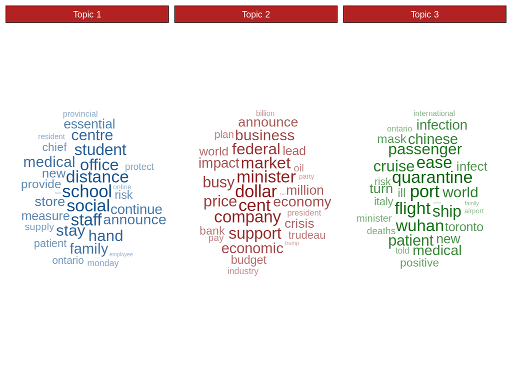

```r
news_word_topic %>%
   rownames_to_column("id") %>%
   mutate(id = as.numeric(id)) %>%
   pivot_longer(-id, names_to = "topic", values_to = "term") %>%
   ggplot(aes(label = term, size = rev(id), color = topic, alpha = rev(id))) +
   geom_text_wordcloud(seed = 123) +
   facet_wrap(~topic, scales = "free") +
   scale_alpha_continuous(range = c(0.4, 1)) +
   scale_color_manual(values = c( "dodgerblue4", "firebrick4", "darkgreen")) +
   theme_minimal() +
   theme(strip.background = element_rect(fill = "firebrick"),
         strip.text.x = element_text(colour = "white"))
```

#### Document-Topic Probabilities

We can also acquire the probability of a document belong to certain topics. We will use this metric to check whether our guest about the interpretation of each topic is make sense and if each topic is different enough subjectively.

##### Social Issues

The following table shows the top 10 news title that has the highest probability to the topic of social issues of coronavirus.

```r
news_doc_topic <- lda_news$theta %>%
   as.data.frame() %>%
   rownames_to_column("id")

news_doc_topic %>%
   arrange(desc(t_1)) %>%
   left_join(covid_clean %>%
                mutate(V1 = as.character(V1)) %>%
                select(V1, title),
             by = c("id" = "V1")) %>%
   column_to_rownames("id") %>%
   select(title, everything()) %>%
   head(10)
```

|  | title | t_1 | t_2 | t_3 |
| --- | --- | --- | --- | --- |
| 4126 | No school for Manitoba K-12 students for 3 weeks starting March 23 | 0.9995219 | 0.0002390629 | 0.0002390629 |
| 234 | Online screening tool for coronavirus up and running in Manitoba, chief nursing officer says | 0.9993318 | 0.0003341129 | 0.0003341129 |
| 2693 | 'Really upsetting': YK1 school board votes to close for remainder of the school year | 0.9992518 | 0.0003741115 | 0.0003741115 |
| 2698 | On-reserve COVID-19 testing set up in Algonquin First Nation after complaints | 0.9992041 | 0.0003979308 | 0.0003979308 |
| 2716 | Universities in Waterloo, Guelph suspend classes amid COVID-19 concerns | 0.9991978 | 0.0004011231 | 0.0004011231 |
| 3060 | COVID-19 concerns prompt West Vancouver school to close early for spring break | 0.9991978 | 0.0004011231 | 0.0004011231 |
| 1768 | School is out! Here's some advice for kids — from kids — on how to pass the time | 0.9991913 | 0.0004043672 | 0.0004043672 |
| 3374 | UPEI ending in-person classes for semester after March 20 | 0.9991847 | 0.0004076641 | 0.0004076641 |
| 3004 | All Edmonton recreation centres to close indefinitely amid COVID-19 worries | 0.9991536 | 0.0004231909 | 0.0004231909 |
| 2744 | 4 COVID-19 cases confirmed in Manitoba, chief provincial public health officer says | 0.9991201 | 0.0004399472 | 0.0004399472 |

##### Politics and Economy

The following table shows the top 10 news title that has the highest probability to belong the topic of politics and economy.

```r
news_doc_topic %>%
   arrange(desc(t_2)) %>%
   left_join(covid_clean %>%
                mutate(V1 = as.character(V1)) %>%
                select(V1, title),
             by = c("id" = "V1")) %>%
   column_to_rownames("id") %>%
   select(title, everything()) %>%
   head(10)
```

|  | title | t_1 | t_2 | t_3 |
| --- | --- | --- | --- | --- |
| 4479 | Alberta premier says layoffs loom as oilpatch warns of 'catastrophic' impact from low prices | 0.0002479544 | 0.9995041 | 0.0002479544 |
| 301 | TSX loses another 8% as Canadian oil price falls to lowest level on record | 0.0003297066 | 0.9993406 | 0.0003297066 |
| 3375 | 'Batten down the hatches': Oilpatch braces as prices plummet | 0.0003307972 | 0.9993384 | 0.0003307972 |
| 531 | Oil plunge, coronavirus fears prompt panic selling on stock markets | 0.0003352330 | 0.9993295 | 0.0003352330 |
| 2406 | 'Agonizing': The prospect of a historic oil glut weighs on crude prices | 0.0003432887 | 0.9993134 | 0.0003432887 |
| 183 | Loonie dips below 70 cents US as coronavirus impact lingers | 0.0003672420 | 0.9992655 | 0.0003672420 |
| 3566 | 'They squandered the good times': Poilievre says Canada lacks 'cushion' to weather economic crises | 0.0004060089 | 0.9991880 | 0.0004060089 |
| 4435 | NDP says Premier Scott Moe is 'playing political games' on possibility of early election | 0.0004076641 | 0.9991847 | 0.0004076641 |
| 3443 | Singh calls on Liberals to start processing applications for financial aid now | 0.0004161465 | 0.9991677 | 0.0004161465 |
| 4285 | Gas prices set to fall 7 cents a litre across Canada on Wednesday: analyst | 0.0004967710 | 0.9990065 | 0.0004967710 |

##### Virus Transmission

The following table shows the top 10 news title that has the highest probability to belong the topic of virus transmission.

```r
news_doc_topic %>%
   arrange(desc(t_3)) %>%
   left_join(covid_clean %>%
                mutate(V1 = as.character(V1)) %>%
                select(V1, title),
             by = c("id" = "V1")) %>%
   column_to_rownames("id") %>%
   select(title, everything()) %>%
   head(10)
```

|  | title | t_1 | t_2 | t_3 |
| --- | --- | --- | --- | --- |
| 3997 | Death toll from new coronavirus outbreak in China reaches 17 | 0.0002255809 | 0.0002255809 | 0.9995488 |
| 996 | Timeline: How the new coronavirus arose and spread | 0.0003083565 | 0.0003083565 | 0.9993833 |
| 1058 | Canadian doctor, WHO team heading to China, where coronavirus death toll tops 900 | 0.0004144219 | 0.0004144219 | 0.9991712 |
| 1092 | Canada ready to help China contain coronavirus if it asks: PM | 0.0004144219 | 0.0004144219 | 0.9991712 |
| 1429 | Patient in Japan infected with new coronavirus from China | 0.0004231909 | 0.0004231909 | 0.9991536 |
| 1407 | France confirms 3 cases as coronavirus outbreak spreads to Europe, U.S. and elsewhere | 0.0004361099 | 0.0004361099 | 0.9991278 |
| 1076 | Quebec couple, both 75, diagnosed with coronavirus aboard cruise | 0.0004418913 | 0.0004418913 | 0.9991162 |
| 4571 | South Korea reports 1st possible case of viral pneumonia | 0.0004478280 | 0.0004478280 | 0.9991043 |
| 1223 | 1st person with coronavirus disease in B.C. has fully recovered, provincial health officer says | 0.0004710316 | 0.0004710316 | 0.9990579 |
| 658 | Ontario's 7th case of coronavirus reported in man who travelled to Iran | 0.0006049607 | 0.0006049607 | 0.9987901 |

#### Topic Proportion over Time

We will illustrate a distant view on the topics in the data over time. Let’s see the range of date when each article is published.

```r
range(covid_clean$publish_date)
```

```
## [1] "2019-12-22 18:36:00" "2020-03-27 08:30:00"
```

The first article start at the end of December 2019 and the latest article is on March 2020. We will group the data into weekly interval and see the proportion of each topic across the weeks.

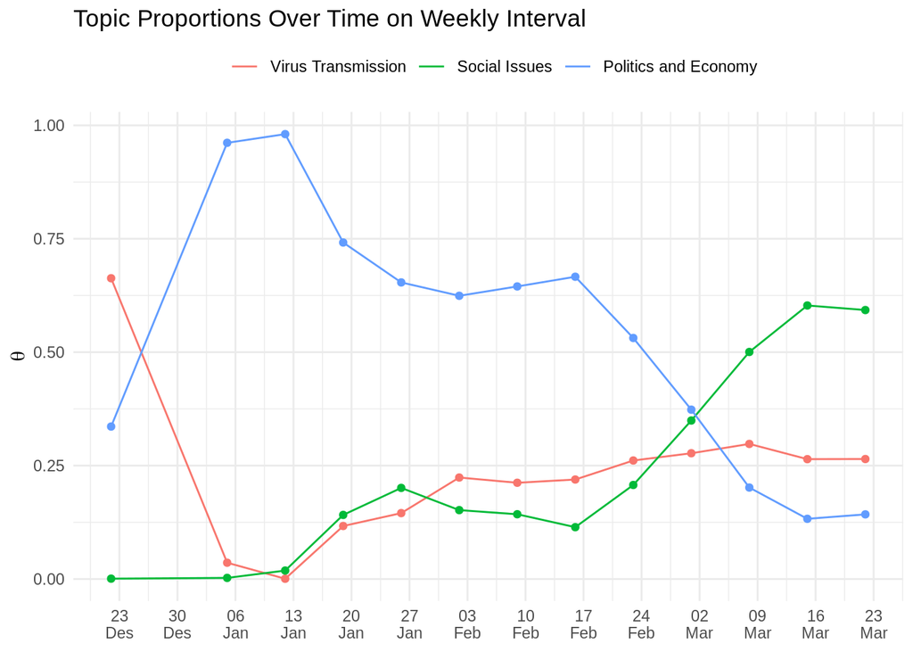

```r
news_doc_topic %>%
   left_join(covid_clean %>%
                mutate(V1 = as.character(V1)) %>%
                select(V1, title, publish_date),
             by = c("id" = "V1")) %>%
   select(-id) %>%
   select(title, everything()) %>%
   pivot_longer(c(t_1, t_2, t_3), names_to = "topic", values_to = "theta") %>%
   mutate(topic = case_when( topic == "t_1" ~ "Social Issues",
                             topic == "t_2" ~ "Virus Transmission",
                             TRUE ~ "Politics and Economy") %>%
             factor(levels = c("Virus Transmission", "Social Issues", "Politics and Economy")),
          publish_date = ymd_hms(publish_date),
          time = floor_date(publish_date, unit = "week") %>% as.Date()
          ) %>%
   group_by(time, topic) %>%
   summarise(theta = mean(theta)) %>%
   ggplot(aes(time, theta, fill = topic, color = topic)) +
   geom_line() +
   geom_point(show.legend = F) +
   theme_minimal() +
   theme(legend.position = "top") +
   scale_x_date(date_breaks = "1 weeks",
                labels = date_format(format = "%d\n%b")) +
   scale_y_continuous() +
   scale_fill_manual(values = c("firebrick", "orange", "dodgerblue3")) +
   labs(x = NULL, y = expression(theta), color = NULL,
        title = "Topic Proportions Over Time on Weekly Interval")
```

However, LDA can’t accurately track the change inside the topic over time since LDA assume that the order of the document does not matter. This assumption may be unrealistic when analyzing long-running collections that span years or centuries, since a topic may change from time to time. For example, the topic Virus Transmission may containt mostly about the transmission and new cases in early 2020 and more about the virus source and characteristics in the later period. These kind of change inside the topic is not detected by LDA. A more advanced and improved version LDA that can accomodate this is the Dynamic Topic Model[^9], a model that respects the ordering of the documents and gives a richer posterior topical structure than LDA.

### Evaluating LDA

Although LDA is an unsupervised learning, we can still measure some of its performance. Traditionally, and still for many practical applications, to evaluate if “the correct thing” has been learned about the corpus, an implicit knowledge and “eyeballing” approaches are used. Ideally, we’d like to capture this information in a single metric that can be maximized, and compared.

#### Eye-Balling Test

The evaluation of a topic model can be done by looking at the content directly, such as the top-n words like what we previously did. We can decide whether the collection of words inside each topic make sense or contain certain similarity.

```r
news_word_topic
```

| Topic 1 | Topic 2 | Topic 3 |
| --- | --- | --- |
| school | dollar | port |
| social | cent | quarantine |
| distance | minister | flight |
| staff | company | ease |
| office | market | wuhan |
| student | support | ship |
| stay | federal | passenger |
| hand | price | cruise |
| centre | busy | patient |
| medical | business | world |

[output cut: 20 more lines]

#### Intrinsic Measures

One of the most popular metric to evaluate a topic model is by looking at the topic coherence. Topic Coherence measures the degree of semantic similarity between the top words in a single topic. The `textmineR` implements a new topic coherence measure based on probability theory. Probabilistic coherence measures how associated words are in a topic, controlling for statistical independence.

> “Suppose you have a corpus of articles from the sports section of a newspaper. A topic with the words {sport, sports, ball, fan, athlete} would look great if you look at correlation, without correcting for independence. But we actually know that it’s a terrible topic because the words are so frequent in this corpus as to be meaningless. In other words, they are highly correlated with each other but they are statistically-independent of each other.”

The intuition of the probabilistic coherence is that it measure how probable a pair of words will come from the same documents than from a random document in the corpus. For example, if we the top 3 words of a topic is `apple`, `banana`, and `cheese`, we can calculate the topic coherence by averaging the following numbers:

1. $P(apple|banana) - P(banana)$
2. $P(apple|cheese) - P(cheese)$
3. $P(banana|cheese) - P(cheese)$

Description:

- $P(apple|banana)$ : The probability that words apple and banana appear together in the same documents
- $P(banana)$ : The probability that the word banana appear in the corpus as a whole

You can get the coherence for each topic by calling the `coherence` object from the LDA models. By default, the topic coherence only look for the top 5 words of each topic.

```r
lda_news$coherence
```

```
##       t_1       t_2       t_3
## 0.1082933 0.1103960 0.1437167
```

```r
dtm_lda <- Matrix::Matrix(as.matrix(dtm_news), sparse = T)
k_list <- seq(10, 100, by = 10)

model_list <- TmParallelApply(X = k_list, FUN = function(k){

  m <- FitLdaModel(dtm = dtm_lda,
                   k = k,
                   iterations = 500,
                   burnin = 200,
                   calc_coherence = TRUE)

  m <- mean(m$coherence)

  return(m)
},
cpus = 4
)
```

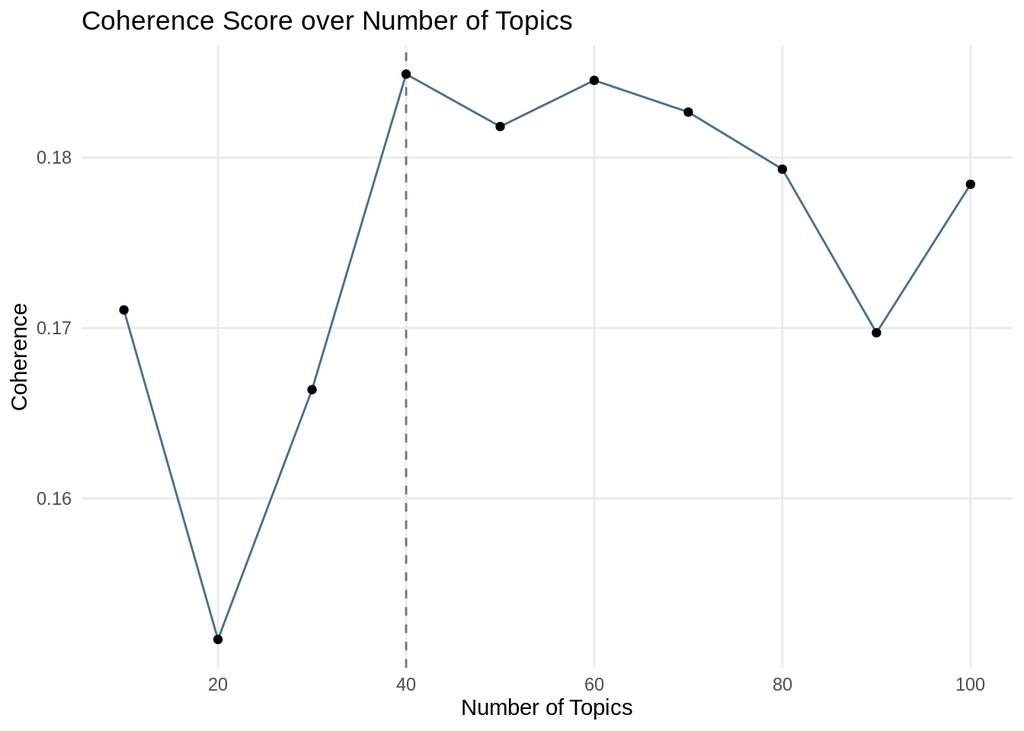

```r
k_list <- seq(10, 100, by = 10)

model_list <- read_rds("coherence result.Rds")

iter_k <- data.frame(
   k = k_list,
   coherence = model_list %>% unlist()
)

iter_k %>%
   mutate(max_k = which(coherence == max(coherence)) * 10) %>%
   ggplot(aes(k, coherence)) +
   geom_vline(aes(xintercept = max_k), alpha = 0.5, lty = "dashed") +
   geom_line(color = "skyblue4") +
   geom_point() +
   scale_x_continuous(breaks = seq(0, 200, 20)) +
   labs(x = "Number of Topics", y = "Coherence", title = "Coherence Score over Number of Topics") +
   theme_minimal() +
   theme(panel.grid.minor = element_blank())
```

The optimal number of topics can be chosen by picking the number of topics that give the highest average coherence.

There are also other methods to evaluate the topic model. It will be too much to discuss them on this article. You can visit Julia Silge blogpost[^10] to see some of the evaluation metrics.

#### Extrinsic Measures

Model performance toward a specific task, such as text classification. If the topics is regarded as a feature for classification model, we can use accuracy or any other classification metrics to check if the topic model is good enough to do the job.

## Document Classification

LDA can also be treated as a model for dimensionality reduction. Each document can be reduce into its associated gamma values. Dimensionality reduction is crucial in text mining since using each word as a feature will result in large dataset and longer computation. In this section, we will compare the performance of text classification using different treatment of dimensionality reduction.

### Import Data

We will import data about workplace review. The data consists of 60,672 observations with the review text and the sentiment.

```r
df <- data.table::fread("data/review.csv")
glimpse(df)
```

```
## Rows: 60,672
## Columns: 2
## $ Sentiment <chr> "positives", "negatives", "positives", "negatives", "positi…
## $ Review    <chr> "People are smart and friendly", "Bureaucracy is slowing th…
```

### Text Cleansing

We will do the usual data cleansing:

- Lowecase all text
- Replace all html symbol
- Replace word elongation
- Remove all puncuations and numbers
- Remove extra white space

```r
df_clean <- df %>%
   mutate(text_clean = Review %>%
             tolower() %>%
             replace_html() %>%
             replace_word_elongation() %>%
             str_replace_all("-", " ") %>%
             str_remove_all("[[:punct:]]") %>%
             str_remove_all("[[0-9]]") %>%
             str_squish() %>%
             str_trim())

df_clean %>% head()
```

| Sentiment | Review | text_clean |
| --- | --- | --- |
| positives | People are smart and friendly | people are smart and friendly |
| negatives | Bureaucracy is slowing things down | bureaucracy is slowing things down |
| positives | 1) Food, food, food. 15+ cafes on main campus (MTV) alone. Mini-kitchens, snacks, drinks, free breakfast/lunch/dinner, all day, errr'day. 2) Benefits/perks. Free 24:7 gym access (on MTV campus). Free … | food food food + cafes on main campus mtv alone mini kitchens snacks drinks free breakfastlunchdinner all day erday benefitsperks free gym access on mtv campus free self service laundry washerdryer av… |
| negatives | 1) Work/life balance. What balance? All those perks and benefits are an illusion. They keep you at work and they help you to be more productive. I've never met anybody at Google who actually time off … | worklife balance what balance all those perks and benefits are an illusion they keep you at work and they help you to be more productive ive never met anybody at google who actually time off on weeken… |
| positives | * If you're a software engineer, you're among the kings of the hill at Google. It's an engineer-driven company without a doubt (that *is* changing, but it's still very engineer-focused). * The perks a… | if youre a software engineer youre among the kings of the hill at google its an engineer driven company without a doubt that is changing but its still very engineer focused the perks are amazing yes f… |
| negatives | * It *is* becoming larger, and with it comes growing pains: bureaucracy, slow to respond to market threats, bloated teams, cross-divisional tension (though nothing remotely approaching that of Microso… | it is becoming larger and with it comes growing pains bureaucracy slow to respond to market threats bloated teams cross divisional tension though nothing remotely approaching that of microsofts intern… |

Next, we inspect the summary of the length of each document. The maximum number of words in a document is 2161 terms.

```r
document_length <- sapply(strsplit(df_clean$text_clean, " "), length)

document_length %>%
   summary()
```

```
##    Min. 1st Qu.  Median    Mean 3rd Qu.    Max.
##     0.0     7.0    14.0    25.7    27.0  2161.0
```

We will only take documents with more than 50 terms/words.

```r
df_clean <- df_clean %>%
   slice(which(document_length > 50))

dim(df_clean)
```

```
## [1] 6271    3
```

### Cross-Validation

We split the data into the training set (80%) and the testing set (20%). We will also check the class proportion of the target variable in the training set.

```r
set.seed(123)
index <- sample(nrow(df_clean), nrow(df_clean)*0.8)

data_train <- df_clean[index, ]
data_test <- df_clean[-index, ]

table(df_clean$Sentiment) %>% prop.table()
```

```
##
## negatives positives
## 0.6451922 0.3548078
```

As we can see, there is a class imbalance between the negative and postive sentiment, so we will upsample the minority class first.

```r
library(caret)
set.seed(123)
data_train <- upSample(x = data_train %>% select(-Sentiment),
                       y = as.factor(data_train$Sentiment), yname = "sentiment")

glimpse(data_train)
```

```
## Rows: 6,474
## Columns: 3
## $ Review     <chr> "As it has grown big, Google has become miserably stagnant…
## $ text_clean <chr> "as it has grown big google has become miserably stagnant …
## $ sentiment  <fct> negatives, negatives, negatives, negatives, negatives, neg…
```

### Document-Term Matrix

Next, we create the document-term matrix (DTM) for each document. The term will be a combination of unigram (1-gram) and bigram (2-gram) for each documents.

```r
stem_hunspell <- function(term) {
    # look up the term in the dictionary
    stems <- hunspell_stem(term)[[1]]

    if (length(stems) == 0) { # if there are no stems, use the original term
        stem <- term
    } else { # if there are multiple stems, use the last one
        stem <- stems[[length(stems)]]
    }
    return(stem)
}

train_term <- data_train %>%
   rownames_to_column("id") %>%
   unnest_tokens(output = "word", input = text_clean) %>%
   anti_join(stop_words)  %>%
   mutate(word = text_tokens(word, stemmer = stem_hunspell) %>% as.character()) %>%
   drop_na(word) %>%
   count(id, word)

train_bigram <- data_train %>%
   rownames_to_column("id") %>%
   unnest_tokens(output = "word", input = text_clean, token = "ngrams", n = 2) %>%
   drop_na(word) %>%
   count(id, word)

test_term <- data_test %>%
   rownames_to_column("id") %>%
   unnest_tokens(output = "word", input = text_clean) %>%
   anti_join(stop_words)  %>%
   mutate(word = text_tokens(word, stemmer = stem_hunspell) %>% as.character()) %>%
   drop_na(word) %>%
   count(id, word)

test_bigram <- data_test %>%
   rownames_to_column("id") %>%
   unnest_tokens(output = "word", input = text_clean, token = "ngrams", n = 2) %>%
   drop_na(word) %>%
   count(id, word)
```

Here is the resulting DTM from the corpus of text data.

```r
dtm_train_review <- train_term %>%
   bind_rows(train_bigram) %>%
   cast_dtm(document = id, term = word, value = n)

dtm_test <- test_term %>%
   bind_rows(test_bigram) %>%
   cast_dtm(document = id, term = word, value = n)

inspect(dtm_train_review)
```

```
## <<DocumentTermMatrix (documents: 6474, terms: 204309)>>
## Non-/sparse entries: 885025/1321811441
## Sparsity           : 100%
## Maximal term length: 48
## Weighting          : term frequency (tf)
## Sample             :
##       Terms
## Docs   amazon company employee if you in the manage of the people team time
##   1016      8       8        3      3      2     11      4      6    3    2
##   1117     20       7        8      5      2      3      3      4    0    7
##   1611      0       0        0      6      3      2      2      9    0    1
##   2298     26       7        6      0      8     29      8      6   32    6
##   2536      6       0        1      3      6      3      5      5    5    4
##   3347     15       5        0      1      2      3      6      9   12   10
##   3355      8       0        2      8      3      3      2      0    0   13
##   4261      2      10        4      4      1      1      1     10    4    5
##   4510      8       0        2      8      3      3      2      0    0   13
##   694       0       1        3      0      1      1      4      5    0    4
```

### Final Preprocessing

```r
word_freq <- findFreqTerms(dtm_train_review, lowfreq =  5, highfreq = nrow(dtm_train_review)*0.8)

dtm_train <- dtm_train_review[ , word_freq ]

dtm_train
```

```
## <<DocumentTermMatrix (documents: 6474, terms: 25908)>>
## Non-/sparse entries: 621283/167107109
## Sparsity           : 100%
## Maximal term length: 30
## Weighting          : term frequency (tf)
```

**LDA**

We will build the LDA topic model for the document-term matrix. We will use number of topic (k) = 50, with 5000 iterations and 4000 burn-in. Since the process is relatively long, we also have saved the previously trained topic model in the next chunk.

The topic distribution for each document ($\theta$) will be used as the features for the machine learning model. Using only 50 topics, we expect a 99.8% dimensionality reduction.

$$Dimensionality\ reduction = 1 - \frac{50}{25908} = 0.998 = 99.8\%$$

```r
dtm_lda <- Matrix::Matrix(as.matrix(dtm_train), sparse = T)

set.seed(123)
lda_review <- FitLdaModel(dtm = dtm_lda,
                        k = 50,
                        iterations = 5000,
                        burnin = 4000
                        )
```

```r
lda_review <- read_rds("lda review.Rds")
```

Finally, we prepare the features and the target variable of the training set for model fitting.

```r
train_y <- data_train$sentiment[ rownames(lda_review$theta) %>% as.numeric() ]

train_x <- lda_review$theta
```

**Bernoullie Convertion**

For the conventional naive bayes, we will convert the numerical value (the frequency of each term in each document) into a categorical whether the term is presence in the document or not.

```r
bernoulli_conv <- function(x){
        x <- as.factor(as.numeric(x > 0))
}

train_bayes <- Matrix::Matrix(as.matrix(dtm_train), sparse = T)

train_bn <- apply(dtm_train, 2, bernoulli_conv)
test_bn <- apply(dtm_test, 2, bernoulli_conv)
```

### Model Fitting and Evaluation

We will use Random Forest and Naive Bayes to fit the data from LDA. We will also compare the performance of the model with a baseline model of Naive Bayes without the dimensionality reduction from LDA.

#### LDA with Random Forest

The random forest model will be trained using 500 trees and `mtry` parameter of 2. The error rate from the Out of Bag (OOB) observation is around 6.3% or similar to 93% of accuracy.

```r
library(randomForest)

set.seed(123)
rf_lda <- randomForest(x = train_x,
                       y = train_y,
                       ntree = 500,
                       mtry = 2)

rf_lda
```

```
##
## Call:
##  randomForest(x = train_x, y = train_y, ntree = 500, mtry = 2)
##                Type of random forest: classification
##                      Number of trees: 500
## No. of variables tried at each split: 2
##
##         OOB estimate of  error rate: 6.27%
## Confusion matrix:
##           negatives positives class.error
## negatives      3135       102  0.03151066
## positives       304      2933  0.09391412
```

Next, we will prepare the testing dataset. To get the features of probability distribution of each topic for each document, we ran the topic model on the DTM of the testing set using only 100 iterations and burn-in of 80.

```r
dtm_lda_test <- Matrix::Matrix(as.matrix(dtm_test), sparse = T)

# Get the topic probabilities for each document
set.seed(123)
test_x <- predict(lda_review,
                  newdata = dtm_lda_test,
                  iterations = 100,
                  burnin = 80
                  )
```

Next, we predict the testing set using the trained model and see the performance via confusion matrix.

```r
set.seed(123)
pred_test <- predict(rf_lda, test_x)
pred_prob <-  predict(rf_lda, test_x, type = "prob")

test_y <- data_test$Sentiment[ rownames(dtm_test) %>% as.numeric() ]

pred_lda <- data.frame(predicted = factor(pred_test, levels = c("positives", "negatives")),
                       actual = factor(test_y, levels = c("positives", "negatives"))
                       )

conf_mat(pred_lda,
         truth = actual,
         estimate = predicted)
```

```
##            Truth
## Prediction  positives negatives
##   positives       271        16
##   negatives       175       793
```

We then translate the confusion matrix into several evaluation matrix, such as accuracy, recall/sensitivity, precision and F1 measure. We also calculate the area under curve (AUC) to check the model sensitivity toward change of classification threshold.

```r
result_lda_rf <- data.frame(
   accuracy = accuracy_vec( truth = pred_lda$actual,
                            estimate = pred_lda$predicted),

   recall = sens_vec( truth = pred_lda$actual,
                      estimate = pred_lda$predicted),

   precision = precision_vec( truth = pred_lda$actual,
                              estimate = pred_lda$predicted),

   F1 = f_meas_vec(truth = pred_lda$actual,
                   estimate = pred_lda$predicted),

   AUC = roc_auc_vec(truth = pred_lda$actual,
                     estimate = pred_prob[, 2])
) %>%
   mutate_all(scales::percent, accuracy = 0.01)

result_lda_rf
```

| accuracy | recall | precision | F1 | AUC |
| --- | --- | --- | --- | --- |
| 84.78% | 60.76% | 94.43% | 73.94% | 94.23% |

#### LDA with Naive Bayes

We will feed the same LDA dataset using the Naive Bayes as comparison.

```r
naive_lda <- naiveBayes(x = train_x,
                        y = train_y)

pred_test <- predict(naive_lda, test_x)
pred_prob <-  predict(naive_lda, test_x, type = "raw")

pred_lda_bayes <- data.frame(predicted = factor(pred_test, levels = c("positives", "negatives")),
                             actual = factor(test_y, levels = c("positives", "negatives"))
                             )

conf_mat(pred_lda_bayes,
         truth = actual,
         estimate = predicted)
```

```
##            Truth
## Prediction  positives negatives
##   positives       316        24
##   negatives       130       785
```

Here are the evaluation metrics for the Naive Bayes model on LDA dataset.

```r
result_lda_bayes <- data.frame(
   accuracy = accuracy_vec( truth = pred_lda_bayes$actual,
                            estimate = pred_lda_bayes$predicted),

   recall = sens_vec( truth = pred_lda_bayes$actual,
                      estimate = pred_lda_bayes$predicted),

   precision = precision_vec( truth = pred_lda_bayes$actual,
                              estimate = pred_lda_bayes$predicted),

   F1 = f_meas_vec(truth = pred_lda_bayes$actual,
                   estimate = pred_lda_bayes$predicted),

   AUC = roc_auc_vec(truth = pred_lda_bayes$actual,
                     estimate = pred_prob[, 2])
) %>%
   mutate_all(scales::percent, accuracy = 0.01)

result_lda_bayes
```

| accuracy | recall | precision | F1 | AUC |
| --- | --- | --- | --- | --- |
| 87.73% | 70.85% | 92.94% | 80.41% | 94.91% |

#### N-gram with Naive Bayes

Lastly, we will train a Naive Bayes model on the original document-term matrix dataset that consist of 25,000+ terms as a baseline or benchmark model. Since the prediction process of naive bayes is taking too much time, we’ve prepared the prediction result in `Rds` format.

```r
naive_gram <- naiveBayes(x = train_bn,
                         y = train_y)

pred_test_gram <- predict(naive_gram, test_bn)
pred_prob_gram <-  predict(naive_gram, test_bn, type = "raw")
```

```r
pred_test_gram <- read_rds("pred_test_gram.Rds")
pred_prob_gram <- read_rds("pred_prob_gram.Rds")
pred_gram_bayes <- data.frame(predicted = factor(pred_test_gram, levels = c("positives", "negatives")),
                             actual = factor(test_y, levels = c("positives", "negatives"))
                             )

conf_mat(pred_gram_bayes,
         truth = actual,
         estimate = predicted)
```

```
##            Truth
## Prediction  positives negatives
##   positives       420        88
##   negatives        26       721
```

Here are the evaluation metrics for the Naive Bayes model on the original dataset.

```r
result_gram_bayes <- data.frame(
   accuracy = accuracy_vec( truth = pred_gram_bayes$actual,
                            estimate = pred_lda_bayes$predicted),

   recall = sens_vec( truth = pred_gram_bayes$actual,
                      estimate = pred_gram_bayes$predicted),

   precision = precision_vec( truth = pred_gram_bayes$actual,
                              estimate = pred_gram_bayes$predicted),

   F1 = f_meas_vec(truth = pred_gram_bayes$actual,
                   estimate = pred_gram_bayes$predicted),

   AUC = roc_auc_vec(truth = pred_gram_bayes$actual,
                     estimate = pred_prob_gram[, 2])
) %>%
   mutate_all(scales::percent, accuracy = 0.01)

result_gram_bayes
```

| accuracy | recall | precision | F1 | AUC |
| --- | --- | --- | --- | --- |
| 87.73% | 94.17% | 82.68% | 88.05% | 97.29% |

```r
result_lda_rf %>%
   bind_rows(result_lda_bayes, result_gram_bayes) %>%
   mutate(
      model = c("Random Forest", "Naive Bayes", "Naive Bayes"),
      method = c("LDA", "LDA", "n-Gram"),
      `n features` = c( 50, 50, ncol(dtm_train) )
   ) %>%
   select(method, model, everything()) %>%
   rename_all(str_to_title)
```

| Method | Model | Accuracy | Recall | Precision | F1 | Auc | N Features |
| --- | --- | --- | --- | --- | --- | --- | --- |
| LDA | Random Forest | 84.78% | 60.76% | 94.43% | 73.94% | 94.23% | 50 |
| LDA | Naive Bayes | 87.73% | 70.85% | 92.94% | 80.41% | 94.91% | 50 |
| n-Gram | Naive Bayes | 87.73% | 94.17% | 82.68% | 88.05% | 97.29% | 25908 |

# Reference

[^1]: [Natural Language Processing Is a Key Engine of AI Market Growth, Enabling 44 Discrete Use Cases Across 17 Industries](https://tractica.omdia.com/newsroom/press-releases/natural-language-processing-is-a-key-engine-of-ai-market-growth-enabling-44-discrete-use-cases-across-17-industries/)
[^2]: [A Simple Introduction to Natural Language Processing](https://becominghuman.ai/a-simple-introduction-to-natural-language-processing-ea66a1747b32)
[^3]: [Applications of Topic Models](https://www.nowpublishers.com/article/DownloadSummary/INR-030)
[^4]: [Latent Dirichlet Allocation](http://www.jmlr.org/papers/volume3/blei03a/blei03a.pdf)
[^5]: [Text Mining with R](https://www.tidytextmining.com/topicmodeling.html)
[^6]: [Bayesian Statistics](https://statswithr.github.io/book/the-basics-of-bayesian-statistics.html)
[^7]: [Hunspell Stemmer](https://github.com/ropensci/hunspell)
[^8]: [Porter Stemming Algorithm](http://snowball.tartarus.org/algorithms/porter/stemmer.html)
[^9]: [Dynamic Topic Models](http://www.cs.columbia.edu/~blei/papers/BleiLafferty2006a.pdf)
[^10]: [Training, evaluating, and interpreting topic models](https://juliasilge.com/blog/evaluating-stm/)